# Gibbs Sampler Prototype: Marginalised Block Update, Adaptive, Anisotropic SPDE

# 1 Model

For each year $t = 1, \dots, M$ we observe the field at the $N$ mesh nodes:

$$Y_t = \mu + \beta_t + \varepsilon_t, \qquad \varepsilon_t \sim
\mathcal{N}(0, \sigma^2 I_N)$$

- $\mu$ is the long-term mean field, with prior $\mu \sim \mathcal{N}(\mu_0, Q_\mu^{-1})$.
- $\beta_t$ is the zero-mean spatial anomaly of year $t$, with prior $\beta_t \sim \mathcal{N}(0, Q_\beta^{-1})$ independently over years.
- $Q_\beta$ is the anisotropic SPDE precision matrix built from the FEM matrices:

$$Q_\beta = \tau^2 \,(\kappa^2 C + G_H)\, C^{-1} \,(\kappa^2 C + G_H),
\qquad G_H = H_{11} K_{11} + H_{12} K_{12} + H_{22} K_{22}$$

The anisotropy matrix $H$ has ratio $\gamma$ and rotation angle $\theta$:

$$H_{11} = \gamma\cos^2\theta + \gamma^{-1}\sin^2\theta, \quad
H_{22} = \gamma\sin^2\theta + \gamma^{-1}\cos^2\theta, \quad
H_{12} = (\gamma - \gamma^{-1})\sin\theta\cos\theta$$

**Sampling scheme.** Each iteration does the following:

1. Gibbs update of $\mu \mid \beta, \sigma^2, Y$.
2. Gibbs update of $\sigma^2 \mid \mu, \beta, Y$ (inverse-gamma).
3. Adaptive random-walk Metropolis–Hastings on $(\log\tau^2, \log\kappa^2, \log\gamma, \theta)$, using the likelihood **with $\beta$ integrated out**, $p(Y - \mu \mid \tau^2, \kappa^2, \gamma, \theta, \sigma^2)$.
4. Joint draw of all $\beta_t$ from their Gaussian full conditional, given the new hyperparameters.

Integrating $\beta$ out in step 3 avoids the strong dependence between the hyperparameters and the latent field that makes a naive Gibbs sampler mix poorly.

> **Known issue: identifiability.** $(\gamma, \theta)$ and $(1/\gamma, \theta + \pi/2)$ give the same $H$, so the posterior has two equivalent modes. Fix it by constraining $\gamma \ge 1$ or $\theta \in [0, \pi/2)$.

# 2 Gibbs and marginalised Metropolis updates

## 2.1 Update of $\mu$

The full conditional of $\mu$ is Gaussian. The data precision is $M/\sigma^2$ per node, and the data mean is the residual $Y - \beta$ averaged over years.

```r
update_mu <- function(
  N,
  M,
  mean_mu_old,
  mean_q_old,
  Y_mat,
  curr_beta,
  curr_sigma2
) {
  q_data <- Diagonal(N, M / curr_sigma2)
  # Data contribution to mu is the residual after removing beta
  mean_data <- 1 / M * rowSums(Y_mat - curr_beta)

  new_q <- q_data + mean_q_old
  rhs <- as.vector(q_data %*% mean_data + mean_q_old %*% mean_mu_old)

  chol_factor <- chol(new_q)
  new_mean <- as.vector(solve(chol_factor, solve(t(chol_factor), rhs)))

  new_mu <- sample_normal_vector(new_mean, new_q, is_precision = TRUE)
  return(new_mu)
}
```

## 2.2 Marginalised Metropolis–Hastings for the SPDE hyperparameters

With $b_t = (Y_t - \mu)/\sigma^2$ and $Q_{\text{post}} = Q_\beta + \sigma^{-2} I$, the log marginal likelihood, up to terms that don’t depend on the hyperparameters, is

$$\log p(Y \mid \cdot) = \frac{M}{2}\log|Q_\beta| -
\frac{M}{2}\log|Q_{\text{post}}| + \frac{1}{2}\sum_t b_t^\top
Q_{\text{post}}^{-1} b_t$$

Both log-determinants come from the Cholesky factors. The proposal is a Gaussian random walk on the unconstrained scale $(\log\tau^2, \log\kappa^2, \log\gamma, \theta)$, and the priors are $\mathcal{N}(0, 5^2)$ on the three logs.

```r
marginal_metropolis_hastings <- function(
  curr_tau2,
  curr_kappa2,
  curr_gamma,
  curr_theta,
  B_mat,
  curr_sigma2,
  C_mat,
  K11,
  K22,
  K12,
  diag_C,
  prop_cov,
  Q_pr_curr,
  chol_pr_curr,
  chol_post_curr,
  M_post_curr,
  log_lik_curr
) {
  M_years <- ncol(B_mat)
  N_nodes <- nrow(B_mat)

  # 1. Proposal in unconstrained space
  curr_vec <- c(log(curr_tau2), log(curr_kappa2), log(curr_gamma), curr_theta)
  prop_vec <- sample_normal_vector(
    mean = curr_vec,
    mat = prop_cov,
    N = 4,
    is_precision = FALSE
  )

  tau2_prop <- exp(prop_vec[1])
  kappa2_prop <- exp(prop_vec[2])
  gamma_prop <- exp(prop_vec[3])
  theta_prop <- prop_vec[4] %% pi

  # 2. Build Proposed SPDE Matrices
  H11 <- gamma_prop *
    (cos(theta_prop)^2) +
    (1 / gamma_prop) * (sin(theta_prop)^2)
  H22 <- gamma_prop *
    (sin(theta_prop)^2) +
    (1 / gamma_prop) * (cos(theta_prop)^2)
  H12 <- (gamma_prop - 1 / gamma_prop) * sin(theta_prop) * cos(theta_prop)

  G_H <- H11 * K11 + H12 * K12 + H22 * K22
  core_prop <- kappa2_prop * C_mat + G_H
  Q_pr_prop <- forceSymmetric(
    tau2_prop * core_prop %*% (Diagonal(x = 1 / diag_C) %*% core_prop)
  )
  Q_post_prop <- Q_pr_prop + Diagonal(N_nodes, 1 / curr_sigma2)

  # 3. Factorizations
  chol_pr_prop <- chol(Q_pr_prop)
  chol_post_prop <- chol(Q_post_prop)
  M_post_prop <- solve(chol_post_prop, solve(t(chol_post_prop), B_mat))

  # 4. MARGINAL Log-Likelihood
  log_det_pr_prop <- 2 * sum(log(diag(chol_pr_prop)))
  log_det_post_prop <- 2 * sum(log(diag(chol_post_prop)))
  quad_prop <- sum(B_mat * M_post_prop)

  log_lik_prop <- 0.5 *
    M_years *
    log_det_pr_prop -
    0.5 * M_years * log_det_post_prop +
    0.5 * quad_prop

  # 5. Log-Priors
  log_prior_curr <- dnorm(log(curr_tau2), 0, 5, log = TRUE) +
    dnorm(log(curr_kappa2), 0, 5, log = TRUE) +
    dnorm(log(curr_gamma), 0, 5, log = TRUE)
  log_prior_prop <- dnorm(prop_vec[1], 0, 5, log = TRUE) +
    dnorm(prop_vec[2], 0, 5, log = TRUE) +
    dnorm(prop_vec[3], 0, 5, log = TRUE)

  # 6. Accept / Reject
  accepted <- FALSE
  if (
    log(runif(1)) <
      (log_lik_prop + log_prior_prop - log_lik_curr - log_prior_curr)
  ) {
    curr_tau2 <- tau2_prop
    curr_kappa2 <- kappa2_prop
    curr_gamma <- gamma_prop
    curr_theta <- theta_prop

    Q_pr_curr <- Q_pr_prop
    chol_pr_curr <- chol_pr_prop
    chol_post_curr <- chol_post_prop
    M_post_curr <- M_post_prop
    log_lik_curr <- log_lik_prop
    accepted <- TRUE
  }

  return(list(
    tau2 = curr_tau2,
    kappa2 = curr_kappa2,
    gamma = curr_gamma,
    theta = curr_theta,
    Q_pr = Q_pr_curr,
    chol_pr = chol_pr_curr,
    chol_post = chol_post_curr,
    M_post = M_post_curr,
    log_lik = log_lik_curr,
    accepted = accepted
  ))
}
```

# 3 Setup and data generation

We simulate data on a $20 \times 20$ grid over $[0, 5]^2$ for $M = 10$ years, with known true parameters. The data generator returns $Y_t = \beta_t + \varepsilon_t$, where $\beta_t$ has mean $\mu$, so the true **anomaly** is $\beta_t - \mu$.

```r
set.seed(42)
x <- seq(0, 5, length.out = 20)
y <- seq(0, 5, length.out = 20)
locs <- as.matrix(expand.grid(x = x, y = y))

mesh <- fm_mesh_2d(loc = locs)
N <- mesh$n
M <- 10
cat("Nr. of vertices (N):", N, "| Years (M):", M, "\n")
```

```
## Nr. of vertices (N): 436 | Years (M): 10
```

```r
matrices <- build_spde_matrices(mesh, manifold = "planar")
K11 <- matrices$K11
K22 <- matrices$K22
K12 <- matrices$K12
C_mat <- matrices$C
diag_C <- Matrix::diag(C_mat)

true_tau <- 1.0
true_kappa <- 1.0
true_gamma <- 2.0
true_theta <- pi / 4
true_sigma_e <- sqrt(0.25)

sim <- generate_toy_data(
  mesh = mesh,
  num_year = M,
  mu_prior_mean = 0.5,
  Q_mu = Diagonal(N, 1),
  tau = true_tau,
  k = true_kappa,
  gamma = true_gamma,
  theta = true_theta,
  sigma_e = true_sigma_e
)

Y_mat <- sim$y_mat
mu_true <- sim$mu_true
# True zero-mean spatial anomaly
true_anomaly_mat <- sim$beta_mat - sim$mu_true
```

# 4 MCMC initialisation

```r
G <- 5000
burnin <- 1000
idx_post <- (burnin + 1):G
samples_sigma2 <- numeric(G)
samples_tau2 <- numeric(G)
samples_kappa2 <- numeric(G)
samples_gamma <- numeric(G)
samples_theta <- numeric(G)
samples_beta1 <- numeric(G)

curr_mu <- rep(0, N)
curr_beta <- matrix(0, nrow = N, ncol = M) # Zero-mean starting field
curr_sigma2 <- 1.0
curr_tau2 <- 0.5
curr_kappa2 <- 0.5
curr_gamma <- 1.0
curr_theta <- 0.0

prior_ig_a <- 0.01
prior_ig_b <- 0.01
prior_mu_prec <- Diagonal(N, 1 / 100)
prior_mu_mean <- rep(0, N)

H11_init <- curr_gamma *
  (cos(curr_theta)^2) +
  (1 / curr_gamma) * (sin(curr_theta)^2)
H22_init <- curr_gamma *
  (sin(curr_theta)^2) +
  (1 / curr_gamma) * (cos(curr_theta)^2)
H12_init <- (curr_gamma - 1 / curr_gamma) * sin(curr_theta) * cos(curr_theta)
G_H_init <- H11_init * K11 + H12_init * K12 + H22_init * K22

core_mat <- curr_kappa2 * C_mat + G_H_init
Q_pr_curr <- forceSymmetric(
  curr_tau2 * core_mat %*% (Diagonal(x = 1 / diag_C) %*% core_mat)
)
chol_pr_curr <- chol(Q_pr_curr)

mcmc_history <- matrix(0, nrow = G, ncol = 4)
colnames(mcmc_history) <- c("log_tau2", "log_kappa2", "log_gamma", "theta")
prop_cov <- diag(x = 0.05^2, nrow = 4)
scale_factor <- (2.38^2) / 4 * 0.7
acc_count <- 0

beta_sum_post <- matrix(0, nrow = N, ncol = M)

# Thinned storage of post burn-in beta draws (for validation)
thin <- 4
keep_iter <- idx_post[idx_post %% thin == 0]
beta_draws <- array(NA_real_, dim = c(N, M, length(keep_iter)))
```

# 5 Main Gibbs loop

This takes about 1.5 minutes for 436 nodes and 5000 iterations.

```r
start_time <- Sys.time()
for (g in 1:G) {
  # Step 1: Update long-term mean mu
  curr_mu <- update_mu(
    N,
    M,
    prior_mu_mean,
    prior_mu_prec,
    Y_mat,
    curr_beta,
    curr_sigma2
  )
  # Step 2: Update sigma2
  eps_mat <- Y_mat - curr_mu - curr_beta
  a_post_sig <- (N * M) / 2 + prior_ig_a
  b_post_sig <- sum(eps_mat^2) / 2 + prior_ig_b
  curr_sigma2 <- 1 / rgamma(1, shape = a_post_sig, rate = b_post_sig)

  # --- BLOCK UPDATE PREPARATION ---
  Y_star <- Y_mat - curr_mu # SPDE explains the residuals
  B_mat <- Y_star / curr_sigma2
  Q_post_curr <- Q_pr_curr + Diagonal(N, 1 / curr_sigma2)
  chol_post_curr <- chol(Q_post_curr)
  M_post_curr <- solve(chol_post_curr, solve(t(chol_post_curr), B_mat))

  log_det_pr_curr <- 2 * sum(log(diag(chol_pr_curr)))
  log_det_post_curr <- 2 * sum(log(diag(chol_post_curr)))
  quad_curr <- sum(B_mat * M_post_curr)
  log_lik_curr <- 0.5 *
    M *
    log_det_pr_curr -
    0.5 * M * log_det_post_curr +
    0.5 * quad_curr

  # Adaptive Logic
  if (g > 200 && (g %% 10 == 0)) {
    emp_cov <- cov(mcmc_history[1:(g - 1), ])
    prop_cov <- scale_factor * emp_cov + diag(1e-4, nrow = 4)
  }

  # Step 3: Marginal M-H
  mh_step <- marginal_metropolis_hastings(
    curr_tau2,
    curr_kappa2,
    curr_gamma,
    curr_theta,
    B_mat,
    curr_sigma2,
    C_mat,
    K11,
    K22,
    K12,
    diag_C,
    prop_cov,
    Q_pr_curr,
    chol_pr_curr,
    chol_post_curr,
    M_post_curr,
    log_lik_curr
  )

  curr_tau2 <- mh_step$tau2
  curr_kappa2 <- mh_step$kappa2
  curr_gamma <- mh_step$gamma
  curr_theta <- mh_step$theta

  Q_pr_curr <- mh_step$Q_pr
  chol_pr_curr <- mh_step$chol_pr
  chol_post_curr <- mh_step$chol_post
  M_post_curr <- mh_step$M_post
  if (mh_step$accepted) {
    acc_count <- acc_count + 1
  }

  # Step 4: Joint Beta update (Anomaly)
  Z_mat <- matrix(rnorm(N * M), nrow = N, ncol = M)
  curr_beta <- as.matrix(M_post_curr + solve(chol_post_curr, Z_mat))

  # Save parameters
  samples_sigma2[g] <- curr_sigma2
  samples_tau2[g] <- curr_tau2
  samples_kappa2[g] <- curr_kappa2
  samples_gamma[g] <- curr_gamma
  samples_theta[g] <- curr_theta
  samples_beta1[g] <- curr_beta[1, 1]
  if (g > burnin) {
    beta_sum_post <- curr_beta + beta_sum_post
  }
  if (g %in% keep_iter) {
    beta_draws[, , match(g, keep_iter)] <- curr_beta
  }

  mcmc_history[g, ] <- c(
    log(curr_tau2),
    log(curr_kappa2),
    log(curr_gamma),
    curr_theta
  )
}
end_time <- Sys.time()

cat(sprintf(
  "Elapsed Time: %.2f seconds\n",
  as.numeric(difftime(end_time, start_time, units = "secs"))
))
```

```
## Elapsed Time: 79.69 seconds
```

```r
cat(sprintf("Acceptance Rate M-H: %.2f%%\n", (acc_count / G) * 100))
```

```
## Acceptance Rate M-H: 18.36%
```

# 6 Convergence diagnostics

## 6.1 Trace plots

These show the **full** chain, so you can see the transient phase and judge whether the burn-in (dashed grey line) is long enough. The red line is the true value.

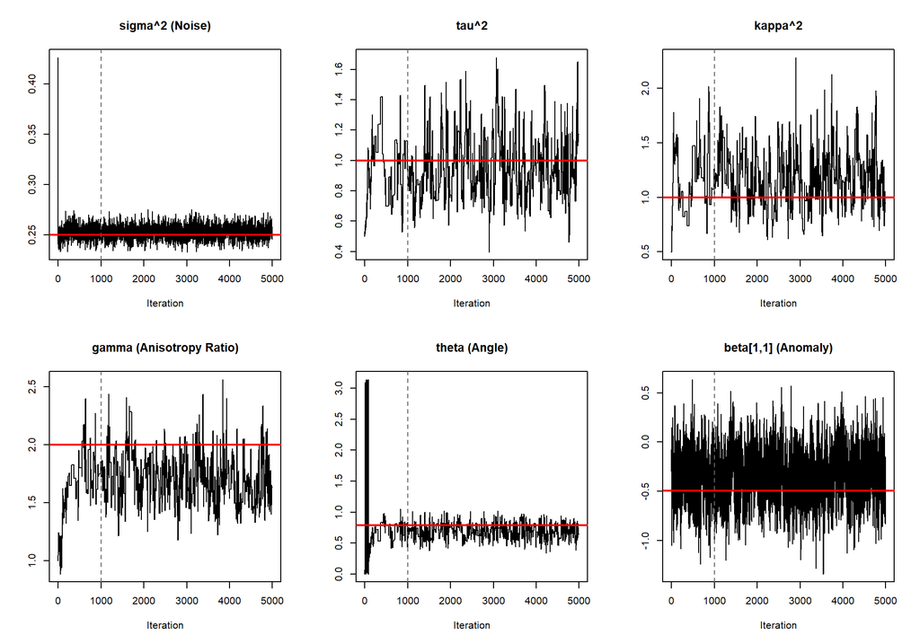

```r
trace_list <- list(
  list(x = samples_sigma2, main = "sigma^2 (Noise)", true = true_sigma_e^2),
  list(x = samples_tau2, main = "tau^2", true = true_tau^2),
  list(x = samples_kappa2, main = "kappa^2", true = true_kappa^2),
  list(x = samples_gamma, main = "gamma (Anisotropy Ratio)", true = true_gamma),
  list(x = samples_theta, main = "theta (Angle)", true = true_theta),
  list(x = samples_beta1, main = "beta[1,1] (Anomaly)", true = true_anomaly_mat[1, 1])
)

par(mfrow = c(2, 3))
for (tr in trace_list) {
  plot(tr$x, type = "l", main = tr$main, xlab = "Iteration", ylab = "")
  abline(v = burnin, lty = 2, col = "grey40")
  abline(h = tr$true, col = "red", lwd = 2)
}
```

```r
par(mfrow = c(1, 1))
```

## 6.2 Autocorrelation and effective sample size

These use the post-burn-in draws only, on the log scale where the Metropolis step moves.

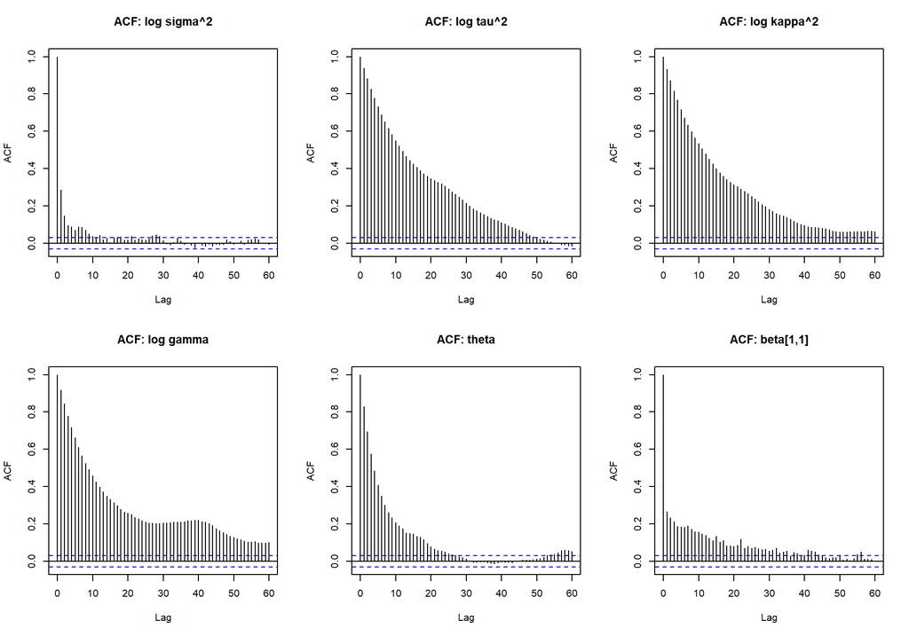

```r
post_draws <- cbind(
  "log sigma^2" = log(samples_sigma2[idx_post]),
  "log tau^2"   = log(samples_tau2[idx_post]),
  "log kappa^2" = log(samples_kappa2[idx_post]),
  "log gamma"   = log(samples_gamma[idx_post]),
  "theta"       = samples_theta[idx_post],
  "beta[1,1]"   = samples_beta1[idx_post]
)

par(mfrow = c(2, 3))
for (j in seq_len(ncol(post_draws))) {
  acf(post_draws[, j], lag.max = 60, main = paste("ACF:", colnames(post_draws)[j]))
}
```

```r
par(mfrow = c(1, 1))

ess <- coda::effectiveSize(coda::mcmc(post_draws))
knitr::kable(
  data.frame(ESS = round(ess), `out of` = length(idx_post), check.names = FALSE),
  caption = "Effective sample size (post burn-in)"
)
```

Effective sample size (post burn-in)

|  | ESS | out of |
| --- | --- | --- |
| log sigma^2 | 1214 | 4000 |
| log tau^2 | 128 | 4000 |
| log kappa^2 | 133 | 4000 |
| log gamma | 172 | 4000 |
| theta | 358 | 4000 |
| beta[1,1] | 476 | 4000 |

## 6.3 Posterior correlation between hyperparameters

A strong negative correlation between $\log\tau^2$ and $\log\kappa^2$ is expected: the marginal variance of the field scales like $1/(4\pi\tau^2\kappa^2)$, so the posterior forms a ridge.

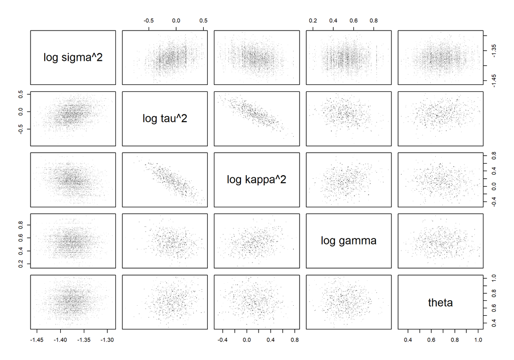

```r
pairs(post_draws[, 1:5], pch = ".", col = adjustcolor("black", 0.3))
```

```r
knitr::kable(round(cor(post_draws[, 1:5]), 2), caption = "Posterior correlations")
```

Posterior correlations

|  | log sigma^2 | log tau^2 | log kappa^2 | log gamma | theta |
| --- | --- | --- | --- | --- | --- |
| log sigma^2 | 1.00 | 0.29 | -0.21 | 0.02 | 0.08 |
| log tau^2 | 0.29 | 1.00 | -0.83 | -0.23 | 0.17 |
| log kappa^2 | -0.21 | -0.83 | 1.00 | 0.25 | -0.12 |
| log gamma | 0.02 | -0.23 | 0.25 | 1.00 | 0.01 |
| theta | 0.08 | 0.17 | -0.12 | 0.01 | 1.00 |

# 7 Posterior estimates vs ground truth

```r
summ <- function(x, true) {
  q <- quantile(x[idx_post], c(0.025, 0.5, 0.975))
  c(True = true, Mean = mean(x[idx_post]), `2.5%` = q[[1]], Median = q[[2]],
    `97.5%` = q[[3]])
}
est_tab <- rbind(
  "sigma^2" = summ(samples_sigma2, true_sigma_e^2),
  "tau^2"   = summ(samples_tau2, true_tau^2),
  "kappa^2" = summ(samples_kappa2, true_kappa^2),
  "gamma"   = summ(samples_gamma, true_gamma),
  "theta"   = summ(samples_theta, true_theta),
  "beta_11" = summ(samples_beta1, true_anomaly_mat[1, 1])
)
knitr::kable(round(est_tab, 4), caption = "Posterior summaries (post burn-in)")
```

Posterior summaries (post burn-in)

|  | True | Mean | 2.5% | Median | 97.5% |
| --- | --- | --- | --- | --- | --- |
| sigma^2 | 0.2500 | 0.2527 | 0.2407 | 0.2526 | 0.2655 |
| tau^2 | 1.0000 | 0.9501 | 0.6237 | 0.9224 | 1.4241 |
| kappa^2 | 1.0000 | 1.1819 | 0.7393 | 1.1558 | 1.7487 |
| gamma | 2.0000 | 1.7154 | 1.3585 | 1.7105 | 2.1654 |
| theta | 0.7854 | 0.6877 | 0.4683 | 0.6854 | 0.9297 |
| beta_11 | -0.4946 | -0.3321 | -0.8499 | -0.3318 | 0.1705 |

## 7.1 Estimated anomaly field

The plot projects vertex values onto a continuous surface using the first-order FEM basis functions.

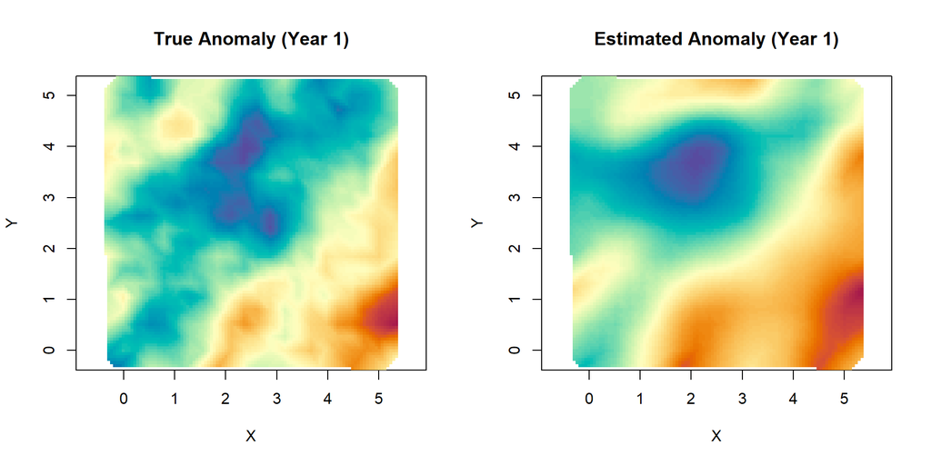

```r
beta_est_mean <- beta_sum_post / (G - burnin)

par(mfrow = c(1, 2))
plot_spde_field(mesh, true_anomaly_mat[, 1], main_title = "True Anomaly (Year 1)")
plot_spde_field(mesh, beta_est_mean[, 1], main_title = "Estimated Anomaly (Year 1)")
```

```r
par(mfrow = c(1, 1))
```

## 7.2 Posterior mean and accuracy metrics

For each node $i$ and year $t$ we summarise the draws of $\beta_{i,t}$ by their posterior mean and compare it with the true anomaly. As a reference, we also compute a naive estimate from the data alone: $Y_t$ minus the node’s average over the years.

```r
# Posterior summaries for each (node, year) from the stored draws
beta_mean <- apply(beta_draws, c(1, 2), mean)
beta_sd <- apply(beta_draws, c(1, 2), sd)

# Errors with respect to the true anomaly
truth <- true_anomaly_mat
err <- beta_mean - truth

rmse <- sqrt(mean(err^2))
mae <- mean(abs(err))
corr <- cor(as.vector(beta_mean), as.vector(truth))

# Naive baseline: the data alone (each year minus the node's average over years)
naive <- Y_mat - rowMeans(Y_mat)
rmse_naive <- sqrt(mean((naive - truth)^2))
mae_naive <- mean(abs(naive - truth))
corr_naive <- cor(as.vector(naive), as.vector(truth))

knitr::kable(
  data.frame(
    Metric = c("RMSE", "MAE", "Correlation with truth"),
    Model = round(c(rmse, mae, corr), 4),
    `Naive baseline` = round(c(rmse_naive, mae_naive, corr_naive), 4),
    check.names = FALSE
  ),
  caption = "Accuracy of the posterior mean of beta"
)
```

Accuracy of the posterior mean of beta

| Metric | Model | Naive baseline |
| --- | --- | --- |
| RMSE | 0.1536 | 0.4839 |
| MAE | 0.1173 | 0.3853 |
| Correlation with truth | 0.8939 | 0.5483 |

## 7.3 Estimated vs true values

Points on the red line $y = x$ are estimated exactly. A slope slightly below 1 is expected, because the prior shrinks extreme values towards 0.

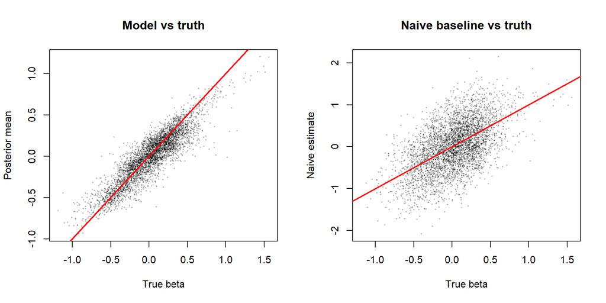

```r
par(mfrow = c(1, 2))
plot(truth, beta_mean, pch = 16, cex = 0.3, col = adjustcolor("black", 0.3),
     xlab = "True beta", ylab = "Posterior mean", main = "Model vs truth")
abline(0, 1, col = "red", lwd = 2)
plot(truth, naive, pch = 16, cex = 0.3, col = adjustcolor("black", 0.3),
     xlab = "True beta", ylab = "Naive estimate", main = "Naive baseline vs truth")
abline(0, 1, col = "red", lwd = 2)
```

```r
par(mfrow = c(1, 1))
```

## 7.4 Accuracy by year

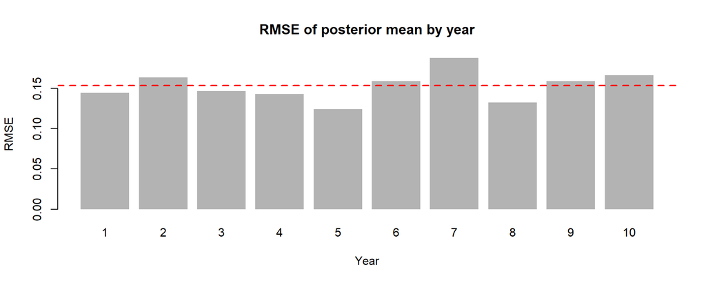

```r
rmse_year <- sqrt(colMeans(err^2))
barplot(rmse_year, names.arg = seq_len(M), xlab = "Year", ylab = "RMSE",
        main = "RMSE of posterior mean by year", col = "grey70", border = NA)
abline(h = rmse, col = "red", lwd = 2, lty = 2) # overall RMSE
```

## 7.5 Maps for one year

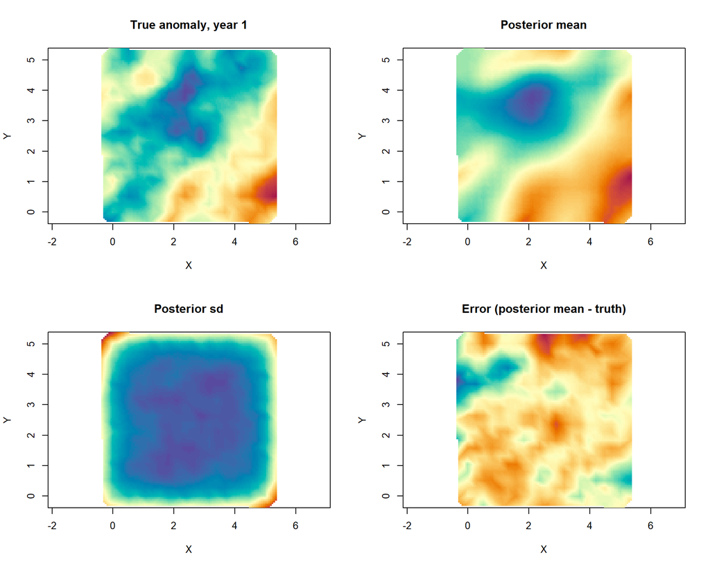

```r
yr <- 1
par(mfrow = c(2, 2))
plot_spde_field(mesh, truth[, yr], main_title = paste("True anomaly, year", yr))
plot_spde_field(mesh, beta_mean[, yr], main_title = "Posterior mean")
plot_spde_field(mesh, beta_sd[, yr], main_title = "Posterior sd")
plot_spde_field(mesh, err[, yr], main_title = "Error (posterior mean - truth)")
```

```r
par(mfrow = c(1, 1))
```